# D2SC ICMA Notebook

Vincent Espana

2024-10-16

# Initial Loading

```r
library(tidyverse)
```

# ICMA 9/9/2024

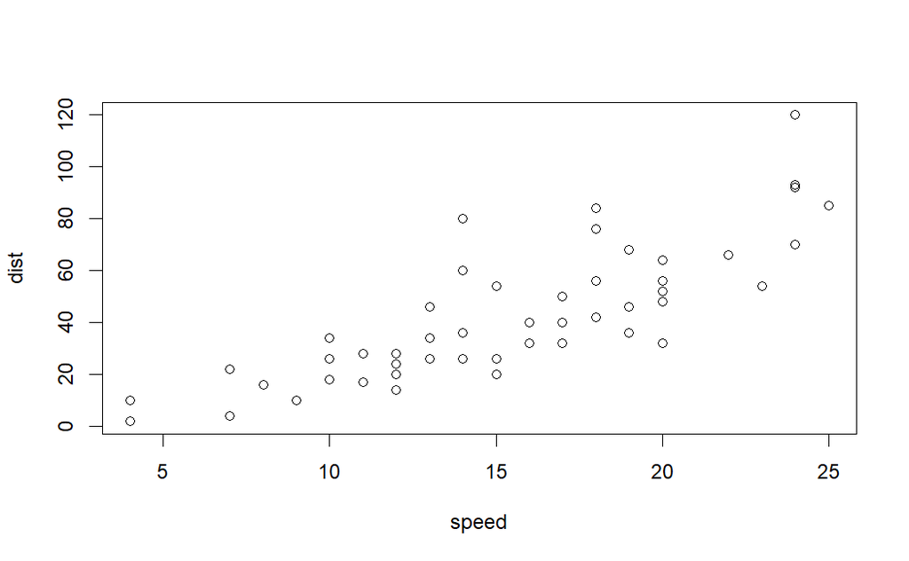

```r
plot(cars)
```

# ICMA 9/11/2024

This is where we put plain text

```r
# this is where we put r code
```

```r
0hno!This_is.a_nightmare <- "hello"
```

```
Error: unexpected symbol in "0hno"
```

```r
ohno_this_is_a_nightmare <- "hello"
# dots also work
```

```r
2+2
```

```
[1] 4
```

```r
x <- 2 + 2
```

```r
?mean
```

```r
mean(c(2, 3, 4))
```

```
[1] 3
```

```r
myVector <- c(2, 3, 4)
```

```r
mean(my_vector)
```

```
Error: object 'my_vector' not found
```

```r
my_vector <- c(2, 3, 4)
```

```r
?sd
```

```r
sd(1:2) ^ 2
```

```
[1] 0.5
```

# ICMA 9/16/2024

```r
#install.packages() last time
library(tidyverse)
```

```r
#some functions cant be used/need more work
stats::filter()
```

```r
#does not work
head(3, billboard)
```

```r
billboard %>%
  head(3)
```

| artist | track | date.entered | wk1 | wk2 | wk3 | wk4 | wk5 | wk6 | wk7 | wk8 | wk9 | wk10 | wk11 | wk12 | wk13 | wk14 | wk15 | wk16 | wk17 | wk18 | wk19 | wk20 | wk21 | wk22 | wk23 | wk24 | wk25 | wk26 | wk27 | … |
| --- | --- | --- | --- | --- | --- | --- | --- | --- | --- | --- | --- | --- | --- | --- | --- | --- | --- | --- | --- | --- | --- | --- | --- | --- | --- | --- | --- | --- | --- | --- |
| 2 Pac | Baby Don't Cry (Keep... | 2000-02-26 | 87 | 82 | 72 | 77 | 87 | 94 | 99 | NA | NA | NA | NA | NA | NA | NA | NA | NA | NA | NA | NA | NA | NA | NA | NA | NA | NA | NA | NA | … |
| 2Ge+her | The Hardest Part Of ... | 2000-09-02 | 91 | 87 | 92 | NA | NA | NA | NA | NA | NA | NA | NA | NA | NA | NA | NA | NA | NA | NA | NA | NA | NA | NA | NA | NA | NA | NA | NA | … |
| 3 Doors Down | Kryptonite | 2000-04-08 | 81 | 70 | 68 | 67 | 66 | 57 | 54 | 53 | 51 | 51 | 51 | 51 | 47 | 44 | 38 | 28 | 22 | 18 | 18 | 14 | 12 | 7 | 6 | 6 | 6 | 5 | 5 | … |

```r
my_numbers <- c(1, 2, 3, 4, 5, 8, 9, 10)
```

```r
mean(my_numbers)
```

```
[1] 5.25
```

```r
my_numbers %>%
  mean()
```

```
[1] 5.25
```

```r
getwd()
```

```
[1] "C:/Users/vince/OneDrive/Documents/GitHub/Data2SciComm/ICMA"
```

```r
mtcars
```

|  | mpg | cyl | disp | hp | drat | wt | qsec | vs | am | gear | carb |
| --- | --- | --- | --- | --- | --- | --- | --- | --- | --- | --- | --- |
| Mazda RX4 | 21.0 | 6 | 160.0 | 110 | 3.90 | 2.620 | 16.46 | 0 | 1 | 4 | 4 |
| Mazda RX4 Wag | 21.0 | 6 | 160.0 | 110 | 3.90 | 2.875 | 17.02 | 0 | 1 | 4 | 4 |
| Datsun 710 | 22.8 | 4 | 108.0 | 93 | 3.85 | 2.320 | 18.61 | 1 | 1 | 4 | 1 |
| Hornet 4 Drive | 21.4 | 6 | 258.0 | 110 | 3.08 | 3.215 | 19.44 | 1 | 0 | 3 | 1 |
| Hornet Sportabout | 18.7 | 8 | 360.0 | 175 | 3.15 | 3.440 | 17.02 | 0 | 0 | 3 | 2 |
| Valiant | 18.1 | 6 | 225.0 | 105 | 2.76 | 3.460 | 20.22 | 1 | 0 | 3 | 1 |
| Duster 360 | 14.3 | 8 | 360.0 | 245 | 3.21 | 3.570 | 15.84 | 0 | 0 | 3 | 4 |
| Merc 240D | 24.4 | 4 | 146.7 | 62 | 3.69 | 3.190 | 20.00 | 1 | 0 | 4 | 2 |
| Merc 230 | 22.8 | 4 | 140.8 | 95 | 3.92 | 3.150 | 22.90 | 1 | 0 | 4 | 2 |
| Merc 280 | 19.2 | 6 | 167.6 | 123 | 3.92 | 3.440 | 18.30 | 1 | 0 | 4 | 4 |

[output cut: 22 more lines]

```r
write_csv(mtcars, #object name
          "mtcars_fromR.csv")
```

```r
mtcars %>%
  rownames_to_column() %>%
  write_csv("mtcars_fromR_rownames.csv")
```

```r
mtcars_read <- read_csv("mtcars_fromR_rownames.csv")
```

# ICMA 9/18/2024

```r
?ChickWeight
```

```r
ChickWeight %>%
  select(weight)
```

|  | weight |
| --- | --- |
| 1 | 42 |
| 2 | 51 |
| 3 | 59 |
| 4 | 64 |
| 5 | 76 |
| 6 | 93 |
| 7 | 106 |
| 8 | 125 |
| 9 | 149 |
| 10 | 171 |

[output cut: 568 more lines]

```r
chick_clean <- ChickWeight %>%
  select(chick_id = Chick,
         diet = Diet,
         age_days = Time,
         weight_gm = weight) #will reorder as well as rename
#will not print because this is only assignment --> will show up in environment
```

equality operator in R is “==”

```r
chick_clean %>%
  arrange(chick_id)
```

| chick_id | diet | age_days | weight_gm |
| --- | --- | --- | --- |
| 18 | 1 | 0 | 39 |
| 18 | 1 | 2 | 35 |
| 16 | 1 | 0 | 41 |
| 16 | 1 | 2 | 45 |
| 16 | 1 | 4 | 49 |
| 16 | 1 | 6 | 51 |
| 16 | 1 | 8 | 57 |
| 16 | 1 | 10 | 51 |
| 16 | 1 | 12 | 54 |
| 15 | 1 | 0 | 41 |

[output cut: 568 more lines]

```r
chick_clean %>%
  mutate(weight_per_day = weight_gm/age_days)
```

[output not shown]

```r
chick_clean %>%
  mutate(weight_lbs = weight_gm/453.6) #mutate will always add to end of dataset
```

|  | chick_id | diet | age_days | weight_gm | weight_lbs |
| --- | --- | --- | --- | --- | --- |
| 1 | 1 | 1 | 0 | 42 | 0.09259259 |
| 2 | 1 | 1 | 2 | 51 | 0.11243386 |
| 3 | 1 | 1 | 4 | 59 | 0.13007055 |
| 4 | 1 | 1 | 6 | 64 | 0.14109347 |
| 5 | 1 | 1 | 8 | 76 | 0.16754850 |
| 6 | 1 | 1 | 10 | 93 | 0.20502646 |
| 7 | 1 | 1 | 12 | 106 | 0.23368607 |
| 8 | 1 | 1 | 14 | 125 | 0.27557319 |
| 9 | 1 | 1 | 16 | 149 | 0.32848325 |
| 10 | 1 | 1 | 18 | 171 | 0.37698413 |

[output cut: 568 more lines]

```r
NA
```

```r
42/453.6
```

```
[1] 0.09259259
```

```r
chick_clean %>%
  mutate(weight_lbs = weight_gm/453.6) %>%
  group_by(diet, age_days) %>%
  summarize(n = n(),
            mean_wgt_gm = mean(weight_gm,),
            mean_wgt_lbs =mean(weight_lbs)) %>%
  filter(age_days == 20)
```

| diet | age_days | n | mean_wgt_gm | mean_wgt_lbs |
| --- | --- | --- | --- | --- |
| 1 | 20 | 17 | 170.4118 | 0.3756873 |
| 2 | 20 | 10 | 205.6000 | 0.4532628 |
| 3 | 20 | 10 | 258.9000 | 0.5707672 |
| 4 | 20 | 9 | 233.8889 | 0.5156281 |

3 things: for each diet group number of chicks, avg gm weight, avg lbs weight on day 20

```r
chick_clean %>%
  filter(age_days == 20) %>%
  mutate(weight_lbs = weight_gm/453.6) %>%
  group_by(diet) %>%
  summarize(n = n(),
            mean_wgt_gm = mean(weight_gm,),
            mean_wgt_lbs =mean(weight_lbs))
```

| diet | n | mean_wgt_gm | mean_wgt_lbs |
| --- | --- | --- | --- |
| 1 | 17 | 170.4118 | 0.3756873 |
| 2 | 10 | 205.6000 | 0.4532628 |
| 3 | 10 | 258.9000 | 0.5707672 |
| 4 | 9 | 233.8889 | 0.5156281 |

```r
mtcars_modified <- read_csv("mtcars_fromR_rownames.csv")
```

```r
glimpse(mtcars_modified)
```

```
Rows: 32
Columns: 12
$ rowname <chr> "Mazda RX4", "Mazda RX4 Wag", "Datsun 710", "Hornet 4 Drive", "Hornet Sportabout", "Valiant"…
$ mpg     <dbl> 21.0, 21.0, 22.8, 21.4, 18.7, 18.1, 14.3, 24.4, 22.8, 19.2, 17.8, 16.4, 17.3, 15.2, 10.4, 10…
$ cyl     <dbl> 6, 6, 4, 6, 8, 6, 8, 4, 4, 6, 6, 8, 8, 8, 8, 8, 8, 4, 4, 4, 4, 8, 8, 8, 8, 4, 4, 4, 8, 6, 8,…
$ disp    <dbl> 160.0, 160.0, 108.0, 258.0, 360.0, 225.0, 360.0, 146.7, 140.8, 167.6, 167.6, 275.8, 275.8, 2…
$ hp      <dbl> 110, 110, 93, 110, 175, 105, 245, 62, 95, 123, 123, 180, 180, 180, 205, 215, 230, 66, 52, 65…
$ drat    <dbl> 3.90, 3.90, 3.85, 3.08, 3.15, 2.76, 3.21, 3.69, 3.92, 3.92, 3.92, 3.07, 3.07, 3.07, 2.93, 3.…
$ wt      <dbl> 2.620, 2.875, 2.320, 3.215, 3.440, 3.460, 3.570, 3.190, 3.150, 3.440, 3.440, 4.070, 3.730, 3…
$ qsec    <dbl> 16.46, 17.02, 18.61, 19.44, 17.02, 20.22, 15.84, 20.00, 22.90, 18.30, 18.90, 17.40, 17.60, 1…
$ vs      <dbl> 0, 0, 1, 1, 0, 1, 0, 1, 1, 1, 1, 0, 0, 0, 0, 0, 0, 1, 1, 1, 1, 0, 0, 0, 0, 1, 0, 1, 0, 0, 0,…
$ am      <dbl> 1, 1, 1, 0, 0, 0, 0, 0, 0, 0, 0, 0, 0, 0, 0, 0, 0, 1, 1, 1, 0, 0, 0, 0, 0, 1, 1, 1, 1, 1, 1,…
$ gear    <dbl> 4, 4, 4, 3, 3, 3, 3, 4, 4, 4, 4, 3, 3, 3, 3, 3, 3, 4, 4, 4, 3, 3, 3, 3, 3, 4, 5, 5, 5, 5, 5,…
$ carb    <dbl> 4, 4, 1, 1, 2, 1, 4, 2, 2, 4, 4, 3, 3, 3, 4, 4, 4, 1, 2, 1, 1, 2, 2, 4, 2, 1, 2, 2, 4, 6, 8,…
```

# ICMA 9/23/2024

```r
billboard
```

| artist | track | date.entered | wk1 | wk2 | wk3 | wk4 | wk5 | wk6 | wk7 | wk8 | wk9 | wk10 | wk11 | wk12 | wk13 | wk14 | wk15 | wk16 | wk17 | wk18 | wk19 | wk20 | wk21 | wk22 | wk23 | wk24 | wk25 | wk26 | wk27 | … |
| --- | --- | --- | --- | --- | --- | --- | --- | --- | --- | --- | --- | --- | --- | --- | --- | --- | --- | --- | --- | --- | --- | --- | --- | --- | --- | --- | --- | --- | --- | --- |
| 2 Pac | Baby Don't Cry (Keep... | 2000-02-26 | 87 | 82 | 72 | 77 | 87 | 94 | 99 | NA | NA | NA | NA | NA | NA | NA | NA | NA | NA | NA | NA | NA | NA | NA | NA | NA | NA | NA | NA | … |
| 2Ge+her | The Hardest Part Of ... | 2000-09-02 | 91 | 87 | 92 | NA | NA | NA | NA | NA | NA | NA | NA | NA | NA | NA | NA | NA | NA | NA | NA | NA | NA | NA | NA | NA | NA | NA | NA | … |
| 3 Doors Down | Kryptonite | 2000-04-08 | 81 | 70 | 68 | 67 | 66 | 57 | 54 | 53 | 51 | 51 | 51 | 51 | 47 | 44 | 38 | 28 | 22 | 18 | 18 | 14 | 12 | 7 | 6 | 6 | 6 | 5 | 5 | … |
| 3 Doors Down | Loser | 2000-10-21 | 76 | 76 | 72 | 69 | 67 | 65 | 55 | 59 | 62 | 61 | 61 | 59 | 61 | 66 | 72 | 76 | 75 | 67 | 73 | 70 | NA | NA | NA | NA | NA | NA | NA | … |
| 504 Boyz | Wobble Wobble | 2000-04-15 | 57 | 34 | 25 | 17 | 17 | 31 | 36 | 49 | 53 | 57 | 64 | 70 | 75 | 76 | 78 | 85 | 92 | 96 | NA | NA | NA | NA | NA | NA | NA | NA | NA | … |
| 98^0 | Give Me Just One Nig... | 2000-08-19 | 51 | 39 | 34 | 26 | 26 | 19 | 2 | 2 | 3 | 6 | 7 | 22 | 29 | 36 | 47 | 67 | 66 | 84 | 93 | 94 | NA | NA | NA | NA | NA | NA | NA | … |
| A*Teens | Dancing Queen | 2000-07-08 | 97 | 97 | 96 | 95 | 100 | NA | NA | NA | NA | NA | NA | NA | NA | NA | NA | NA | NA | NA | NA | NA | NA | NA | NA | NA | NA | NA | NA | … |
| Aaliyah | I Don't Wanna | 2000-01-29 | 84 | 62 | 51 | 41 | 38 | 35 | 35 | 38 | 38 | 36 | 37 | 37 | 38 | 49 | 61 | 63 | 62 | 67 | 83 | 86 | NA | NA | NA | NA | NA | NA | NA | … |
| Aaliyah | Try Again | 2000-03-18 | 59 | 53 | 38 | 28 | 21 | 18 | 16 | 14 | 12 | 10 | 9 | 8 | 6 | 1 | 2 | 2 | 2 | 2 | 3 | 4 | 5 | 5 | 6 | 9 | 13 | 14 | 16 | … |
| Adams, Yolanda | Open My Heart | 2000-08-26 | 76 | 76 | 74 | 69 | 68 | 67 | 61 | 58 | 57 | 59 | 66 | 68 | 61 | 67 | 59 | 63 | 67 | 71 | 79 | 89 | NA | NA | NA | NA | NA | NA | NA | … |

[output cut: 307 more lines]

```r
billboard %>%
  pivot_longer(wk1:wk76)
```

| artist | track | date.entered | name | value |
| --- | --- | --- | --- | --- |
| 2 Pac | Baby Don't Cry (Keep... | 2000-02-26 | wk1 | 87 |
| 2 Pac | Baby Don't Cry (Keep... | 2000-02-26 | wk2 | 82 |
| 2 Pac | Baby Don't Cry (Keep... | 2000-02-26 | wk3 | 72 |
| 2 Pac | Baby Don't Cry (Keep... | 2000-02-26 | wk4 | 77 |
| 2 Pac | Baby Don't Cry (Keep... | 2000-02-26 | wk5 | 87 |
| 2 Pac | Baby Don't Cry (Keep... | 2000-02-26 | wk6 | 94 |
| 2 Pac | Baby Don't Cry (Keep... | 2000-02-26 | wk7 | 99 |
| 2 Pac | Baby Don't Cry (Keep... | 2000-02-26 | wk8 | NA |
| 2 Pac | Baby Don't Cry (Keep... | 2000-02-26 | wk9 | NA |
| 2 Pac | Baby Don't Cry (Keep... | 2000-02-26 | wk10 | NA |

[output cut: 990 more lines]

```r
billboard_longer <- billboard %>%
  pivot_longer(cols = starts_with("wk"),
               names_to = "week",
               values_to = "position",
               names_prefix = "wk",
               values_drop_na = TRUE)

billboard_longer
```

| artist | track | date.entered | week | position |
| --- | --- | --- | --- | --- |
| 2 Pac | Baby Don't Cry (Keep... | 2000-02-26 | 1 | 87 |
| 2 Pac | Baby Don't Cry (Keep... | 2000-02-26 | 2 | 82 |
| 2 Pac | Baby Don't Cry (Keep... | 2000-02-26 | 3 | 72 |
| 2 Pac | Baby Don't Cry (Keep... | 2000-02-26 | 4 | 77 |
| 2 Pac | Baby Don't Cry (Keep... | 2000-02-26 | 5 | 87 |
| 2 Pac | Baby Don't Cry (Keep... | 2000-02-26 | 6 | 94 |
| 2 Pac | Baby Don't Cry (Keep... | 2000-02-26 | 7 | 99 |
| 2Ge+her | The Hardest Part Of ... | 2000-09-02 | 1 | 91 |
| 2Ge+her | The Hardest Part Of ... | 2000-09-02 | 2 | 87 |
| 2Ge+her | The Hardest Part Of ... | 2000-09-02 | 3 | 92 |

[output cut: 990 more lines]

```r
NA
```

```r
billboard_longer %>%
  pivot_wider(names_from = "week",
              values_from = "position")
```

[output not shown]

[output cut: 307 more lines]

```r
?pivot_longer
```

```r
billboard %>%
  separate(col = date.entered,
           into = c("year", "month", "day"))
```

| artist | track | year | month | day | wk1 | wk2 | wk3 | wk4 | wk5 | wk6 | wk7 | wk8 | wk9 | wk10 | wk11 | wk12 | wk13 | wk14 | wk15 | wk16 | wk17 | wk18 | wk19 | wk20 | wk21 | wk22 | wk23 | wk24 | wk25 | … |
| --- | --- | --- | --- | --- | --- | --- | --- | --- | --- | --- | --- | --- | --- | --- | --- | --- | --- | --- | --- | --- | --- | --- | --- | --- | --- | --- | --- | --- | --- | --- |
| 2 Pac | Baby Don't Cry (Keep... | 2000 | 02 | 26 | 87 | 82 | 72 | 77 | 87 | 94 | 99 | NA | NA | NA | NA | NA | NA | NA | NA | NA | NA | NA | NA | NA | NA | NA | NA | NA | NA | … |
| 2Ge+her | The Hardest Part Of ... | 2000 | 09 | 02 | 91 | 87 | 92 | NA | NA | NA | NA | NA | NA | NA | NA | NA | NA | NA | NA | NA | NA | NA | NA | NA | NA | NA | NA | NA | NA | … |
| 3 Doors Down | Kryptonite | 2000 | 04 | 08 | 81 | 70 | 68 | 67 | 66 | 57 | 54 | 53 | 51 | 51 | 51 | 51 | 47 | 44 | 38 | 28 | 22 | 18 | 18 | 14 | 12 | 7 | 6 | 6 | 6 | … |
| 3 Doors Down | Loser | 2000 | 10 | 21 | 76 | 76 | 72 | 69 | 67 | 65 | 55 | 59 | 62 | 61 | 61 | 59 | 61 | 66 | 72 | 76 | 75 | 67 | 73 | 70 | NA | NA | NA | NA | NA | … |
| 504 Boyz | Wobble Wobble | 2000 | 04 | 15 | 57 | 34 | 25 | 17 | 17 | 31 | 36 | 49 | 53 | 57 | 64 | 70 | 75 | 76 | 78 | 85 | 92 | 96 | NA | NA | NA | NA | NA | NA | NA | … |
| 98^0 | Give Me Just One Nig... | 2000 | 08 | 19 | 51 | 39 | 34 | 26 | 26 | 19 | 2 | 2 | 3 | 6 | 7 | 22 | 29 | 36 | 47 | 67 | 66 | 84 | 93 | 94 | NA | NA | NA | NA | NA | … |
| A*Teens | Dancing Queen | 2000 | 07 | 08 | 97 | 97 | 96 | 95 | 100 | NA | NA | NA | NA | NA | NA | NA | NA | NA | NA | NA | NA | NA | NA | NA | NA | NA | NA | NA | NA | … |
| Aaliyah | I Don't Wanna | 2000 | 01 | 29 | 84 | 62 | 51 | 41 | 38 | 35 | 35 | 38 | 38 | 36 | 37 | 37 | 38 | 49 | 61 | 63 | 62 | 67 | 83 | 86 | NA | NA | NA | NA | NA | … |
| Aaliyah | Try Again | 2000 | 03 | 18 | 59 | 53 | 38 | 28 | 21 | 18 | 16 | 14 | 12 | 10 | 9 | 8 | 6 | 1 | 2 | 2 | 2 | 2 | 3 | 4 | 5 | 5 | 6 | 9 | 13 | … |
| Adams, Yolanda | Open My Heart | 2000 | 08 | 26 | 76 | 76 | 74 | 69 | 68 | 67 | 61 | 58 | 57 | 59 | 66 | 68 | 61 | 67 | 59 | 63 | 67 | 71 | 79 | 89 | NA | NA | NA | NA | NA | … |

[output cut: 307 more lines]

```r
billboard %>%
  unite(col = c(year, month, day),
        into = "date")
```

```
Error in `unite()`:
! Arguments in `...` must be passed by position, not name.
✖ Problematic argument:
• into = "date"
Backtrace:
 1. billboard %>% unite(col = c(year, month, day), into = "date")
 2. tidyr::unite(., col = c(year, month, day), into = "date")
```

# ICMA 9/25/2024

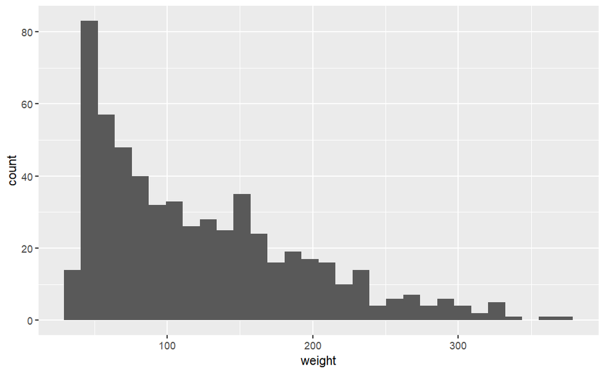

```r
ChickWeight %>%
  ggplot(aes(x = weight)) + # provide the aesthetic mapping
   geom_histogram()
```

cant use pipe functions for geom histogram

[output not shown]

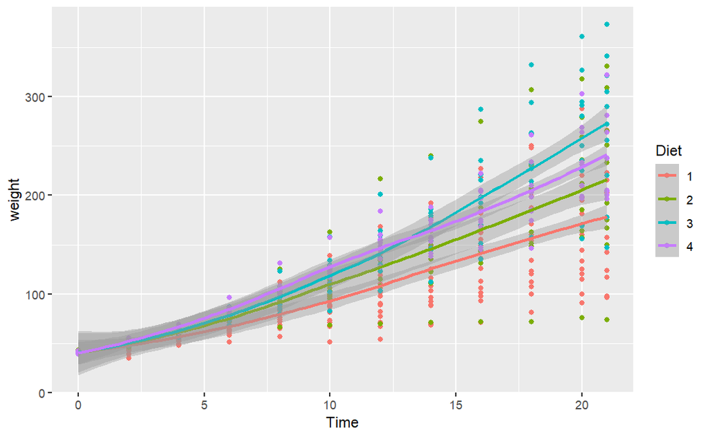

```r
ChickWeight %>%
  ggplot(aes(y = weight,
             x = Time,
             color = Diet)) +
  geom_point() + geom_smooth()
```

kind of diet missing, need more information ^will add above noise = random variability

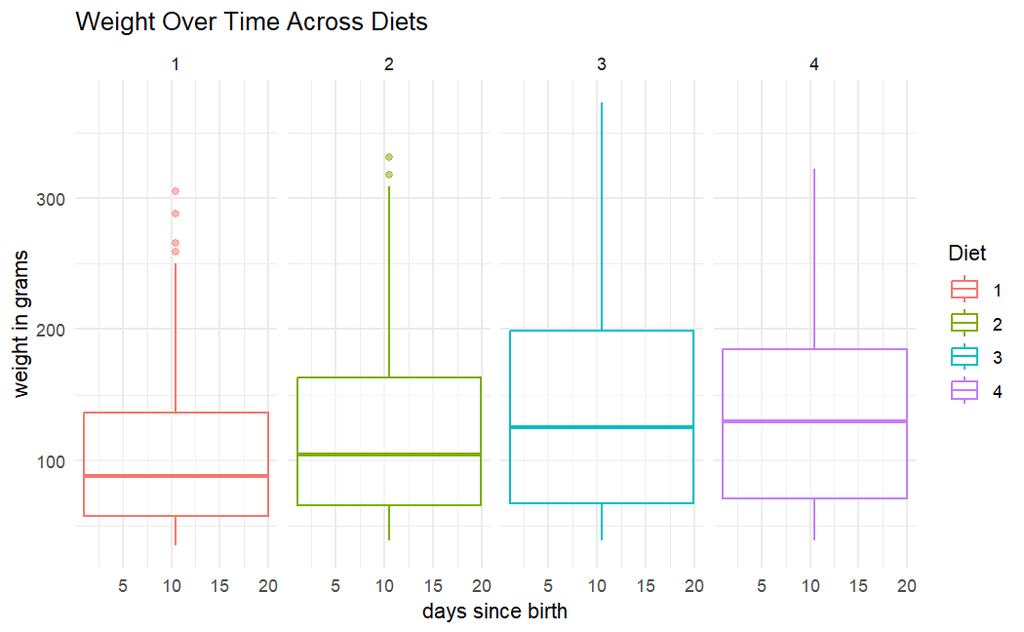

```r
ChickWeight %>%
  ggplot(aes(y = weight,
             x = Time,
             color = Diet)) +
  geom_boxplot(alpha = 0.5) + # make a lil transparent
  #geom_smooth(se = FALSE) + #remove error bands
  theme_minimal() + # using a premade theme to change appearance
  facet_grid(~Diet) +
  labs(y = "weight in grams",
       x = "days since birth",
       title = "Weight Over Time Across Diets")
```

```r
ggsave("chick_weightovertime.png", width = 9 , length = 8)
```

```
Error in f(...) : unused argument (length = 8)
```

# ICMA 10/7/2024

types: numeric, character, logical shared functions: ypeof() - find type of object numeric: integers, doubles (r default)

doubles do not need decimals be careful if you do as.integer(“hello”) -> will not give error will give warning, it will convert to NA (can’t parse as number)

```r
as.numeric("12") #digits can parse into numbers
```

```
[1] 12
```

```r
my_double <- 12.9
typeof(my_double)
```

```
[1] "double"
```

```r
as.integer(my_double) #truncate not round
```

```
[1] 12
```

```r
as.character(my_double)
```

```
[1] "12.9"
```

NA introduced by coercion NA is logical used as missing value indicator 0 is a value, null is a null object

“missing” in sense of does not exist in R

```r
2==NA #result is NA (does not know) - does not know if it is equal to 2 because it does not know if it is
```

```
[1] NA
```

```r
NA==NA
```

```
[1] NA
```

```r
my_values <- c(1,3,5,NA,8,10)
mean(my_values)
```

```
[1] NA
```

```r
#typically can override this by adding a na.rm = TRUE argument to remove the NAs
mean(my_values, na.rm = TRUE) #ignore NA
```

```
[1] 5.4
```

single or/and will evaulate all double or/and will evaulate until one

prediction: true true true true true

```r
(3 / 4) > 0 && (8 + 1 - 7) == 2
```

```
[1] TRUE
```

```r
(5 / 2) == 1 | (2 / 1) > 0 # evaluates all
```

```
[1] TRUE
```

```r
(5 * (5-3)) == 10 || (10 / 2) < 4 # evaluates until one
```

```
[1] TRUE
```

```r
is.numeric(mean(c(38,12,123.7,4.32)))
```

```
[1] TRUE
```

```r
#TRUE would mean that the mean of those numbers is a numeric in R

((7/2) == 3.5) & TRUE | NA
```

```
[1] TRUE
```

```r
NA & TRUE # NA since NA is neither TRUE or FALSE
```

```
[1] NA
```

```r
NA & NA # NA
```

```
[1] NA
```

# ICMA 10/9/2024

scalars, vectors, lists, data frames, tibbles

scalar: single value, like a number or string can me numeric (int, dbl), char, string

vector: a series of elements that have the same type - numbers can be stored as strings, how to know –> quotations

- because vectors have to have the same type, R will coerce things to be the same type

```r
c("1", 2, 3 ,4)
```

```
[1] "1" "2" "3" "4"
```

```r
c(2, 3, 4)
```

```
[1] 2 3 4
```

string has higher precedence than ints during coercion

lists: objects that can store multiple things of different types, including additional vectors –> use list()

```r
my_list <- list("letters" = c("A", "L", "J", "H"),
                "numbers" = 4:8,
                "more_numbers" = 10:30)

my_list
```

```
$letters
[1] "A" "L" "J" "H"

$numbers
[1] 4 5 6 7 8

$more_numbers
 [1] 10 11 12 13 14 15 16 17 18 19 20 21 22 23 24 25 26 27 28 29 30
```

single brackets [] will return the list double brackets [[]] will return the values within the list; can also use $

data frame: each element is of the same length and are bound together –> will get error if diff length

use data.frame

also use [], [[]], and $ to access elements

tibble:a modern reimagining of the data.frame - lazy and surly

create a tibble: 1. using a list of vectors using tibble() 2. type out row wise using tribble()

```r
age_data <- tribble(
                    ~id, ~age,
                    1, 8,
                    2, 10,
                    3, 8,
                    5, 9

)

gender_data <- tribble(
                        ~id, ~gender,
                        1, "f",
                        2, "m",
                        3, "nb",
                        4, "m",
                        6, "f"
)

age_data
```

| id | age |
| --- | --- |
| 1 | 8 |
| 2 | 10 |
| 3 | 8 |
| 5 | 9 |

```r
gender_data
```

| id | gender |
| --- | --- |
| 1 | f |
| 2 | m |
| 3 | nb |
| 4 | m |
| 6 | f |

```r
NA
```

```r
full_join(age_data, gender_data)
```

| id | age | gender |
| --- | --- | --- |
| 1 | 8 | f |
| 2 | 10 | m |
| 3 | 8 | nb |
| 5 | 9 | NA |
| 4 | NA | m |
| 6 | NA | f |

```r
bind_cols(age_data, gender_data)
```

```
Error in `bind_cols()`:
! Can't recycle `..1` (size 4) to match `..2` (size 5).
Backtrace:
 1. dplyr::bind_cols(age_data, gender_data)
```

```r
bind_rows(age_data, gender_data)
```

| id | age | gender |
| --- | --- | --- |
| 1 | 8 | NA |
| 2 | 10 | NA |
| 3 | 8 | NA |
| 5 | 9 | NA |
| 1 | NA | f |
| 2 | NA | m |
| 3 | NA | nb |
| 4 | NA | m |
| 6 | NA | f |

```r
NA
```

# ICMA 10/16/2024

ITERATIONS AND LOOPS - often need to do the same thing over and over again - functions help solve this program by packaging together a bunch of code - loops help run the same code over and over again through iterations

```r
mean(c(1,2,3))
```

```
[1] 2
```

```r
(1+2+3)/3
```

```
[1] 2
```

```r
vec <- c(1,2,3)

(vec[1]+vec[2]+vec[3])/length(vec)
```

```
[1] 2
```

for loop iterates over a vector and executes R code after every iteration general syntax:

```r
for(var in seq){
  expr
}
```

example

```r
for (i in 1:10) {

  i <- i^2
  print(i)
}
```

```
[1] 1
[1] 4
[1] 9
[1] 16
[1] 25
[1] 36
[1] 49
[1] 64
[1] 81
[1] 100
```

```r
fave_number <- tribble(~name, ~number,
                       "MC", 8,
                       "AP", 9,
                       "NG", 12,
                       "VE", 6,
                       "AL", 17,
                       "AR", 3,
                       "MC", 7,
                       "RK", 8,
                       "AC", 4,
                       "SC", 21,
                       "KK", 16,
                       "RK", 28,
                       "VK", 17,
                       "MH", 12
                        )
```

1. for loop to print fave number

```r
for (i in fave_number$number) {

  print(i)

}
```

```
[1] 8
[1] 9
[1] 12
[1] 6
[1] 17
[1] 3
[1] 7
[1] 8
[1] 4
[1] 21
[1] 16
[1] 28
[1] 17
[1] 12
```

fave_number$number is different than fave_number[“number”]… why?

```r
typeof(fave_number$number) #type of the vector
```

```
[1] "double"
```

```r
typeof(fave_number["number"]) #type of the list
```

```
[1] "list"
```

one square bracket means pepper is in packaging in jar two square brackt means actual pepper is in jar

```r
length(fave_number)
```

```
[1] 2
```

2. output for each person –> **’s fave number is**

```r
for (i in seq_along(fave_number$name)) {

  print(str_c(fave_number$name[i], "'s favorite number is ", fave_number$number[i]))

}
```

```
[1] "MC's favorite number is 8"
[1] "AP's favorite number is 9"
[1] "NG's favorite number is 12"
[1] "VE's favorite number is 6"
[1] "AL's favorite number is 17"
[1] "AR's favorite number is 3"
[1] "MC's favorite number is 7"
[1] "RK's favorite number is 8"
[1] "AC's favorite number is 4"
[1] "SC's favorite number is 21"
[1] "KK's favorite number is 16"
[1] "RK's favorite number is 28"
[1] "VK's favorite number is 17"
[1] "MH's favorite number is 12"
```

```r
?seq_along
```

```r
mtcars
```

|  | mpg | cyl | disp | hp | drat | wt | qsec | vs | am | gear | carb |
| --- | --- | --- | --- | --- | --- | --- | --- | --- | --- | --- | --- |
| Mazda RX4 | 21.0 | 6 | 160.0 | 110 | 3.90 | 2.620 | 16.46 | 0 | 1 | 4 | 4 |
| Mazda RX4 Wag | 21.0 | 6 | 160.0 | 110 | 3.90 | 2.875 | 17.02 | 0 | 1 | 4 | 4 |
| Datsun 710 | 22.8 | 4 | 108.0 | 93 | 3.85 | 2.320 | 18.61 | 1 | 1 | 4 | 1 |
| Hornet 4 Drive | 21.4 | 6 | 258.0 | 110 | 3.08 | 3.215 | 19.44 | 1 | 0 | 3 | 1 |
| Hornet Sportabout | 18.7 | 8 | 360.0 | 175 | 3.15 | 3.440 | 17.02 | 0 | 0 | 3 | 2 |
| Valiant | 18.1 | 6 | 225.0 | 105 | 2.76 | 3.460 | 20.22 | 1 | 0 | 3 | 1 |
| Duster 360 | 14.3 | 8 | 360.0 | 245 | 3.21 | 3.570 | 15.84 | 0 | 0 | 3 | 4 |
| Merc 240D | 24.4 | 4 | 146.7 | 62 | 3.69 | 3.190 | 20.00 | 1 | 0 | 4 | 2 |
| Merc 230 | 22.8 | 4 | 140.8 | 95 | 3.92 | 3.150 | 22.90 | 1 | 0 | 4 | 2 |
| Merc 280 | 19.2 | 6 | 167.6 | 123 | 3.92 | 3.440 | 18.30 | 1 | 0 | 4 | 4 |

[output cut: 22 more lines]

```r
NA
```

everything(), map(), across()

while(cond) –> while something is true do this thing